# Instructor Notes 2: Exploratory Data Analysis I

### Ordinal variables (i.e., ordered categories)

Recall that ordinal variables have an *order* to them, but they can only take a few discrete values. A common example is star rating systems, e.g., Amazon star ratings, which clearly have an order to them, but can only take the values 1, 2, 3, 4, or 5.

The correct way to plot an ordinal variable is with a barplot:

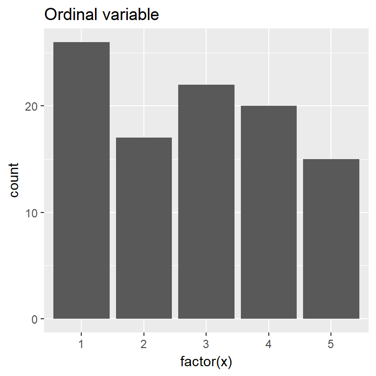

```r
# Simulate ordinal variable with possible values 1-5
x <- sample(1:5, 100, replace=TRUE)
df <- data.frame(x)

# Plot
ggplot(df, aes(x=factor(x))) + geom_bar() + ggtitle('Ordinal variable')
```

A common mistake is to confuse histograms and barplots. They are similar, but they are NOT the same. A histogram does not have any space between the bars, reflecting the fact that there IS no space between the bins. In contrast, a bar plot has spaces between the bars, reflecting the fact that values between these spaces are impossible. This might not seem important, but if you use the wrong type of plot for your variables, it makes your work look sloppy and calls into question whether you understand this basic distinction between continuous and discrete variables.

An important related point is that you can NOT use linear regression with an ordinal target variable because it will predict impossible values (e.g., with the Amazon star ratings example, a linear regression could predict a star rating of 1.2 or 6, which are impossible values). Instead, if you have an ordinal outcome variable, you can transform it into a binary variable and model it with logistic regression.

The easiest way to bin an ordinal variable is by using an `ifelse` statement. This is an incredibly useful function that you should master:

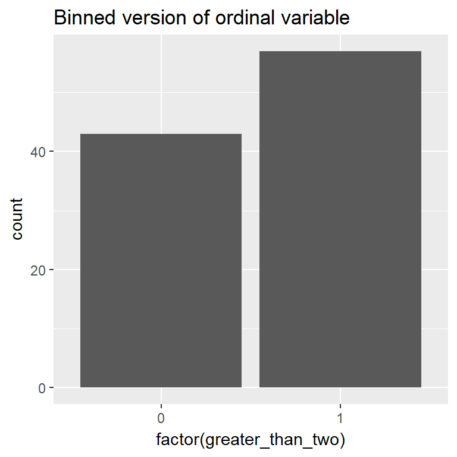

```r
# Bin 1-5 ratings into a binary variable indicating whether the value is greater than two
df$greater_than_two <- ifelse(df$x > 2, 1, 0)

# Plot
ggplot(df, aes(x=factor(greater_than_two))) +
  geom_bar() + ggtitle('Binned version of ordinal variable')
```

You can read the `ifelse` statement like this: If `df$x` is greater than 2, let the new variable be 1, otherwise let the new variable be 0. Also note the use of the `factor` function in the `ggplot`, which tells R to treat this as a categorical (factor) rather than a numerical variable. If you don’t use the `factor` function, the x-axis of the plot may show a range of numerical values such as `0.5` and `1.5` rather than only the binary numbers `0` and `1`, which shows that `ggplot` thinks it is a numerical variable rather than categorical.

If you have an ordinal *predictor* variable, you do not necessarily need to bin it. Whether you bin it depends on whether the numbers have a linear relationship to the target variable. We will discuss this more next week when we get into multivariable plotting. For now, you should only worry about binning ordinal *target variables*. For predictor variables, simply plot with a barplot and describe the distribution.

You might be wondering, how should you choose the cutoff for binning an ordinal variable into two groups? Sometimes there is a very obvious cutoff point. But other times, as in the example above, it isn’t very clear where to draw the line. If there is no natural breakpoint in the distribution, I would try to cut it roughly in half. So in the example above, a threshold of either 2 or 3 would be fine. However, take the example below:

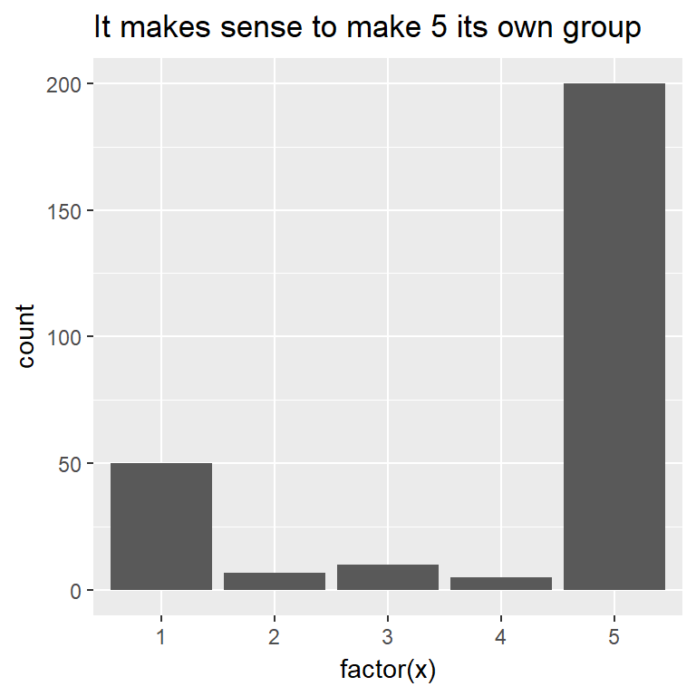

```r
df <- data.frame(x = c(rep(5, 200), rep(4, 5), rep(3, 10), rep(2, 7), rep(1, 50)))

ggplot(df, aes(x=factor(x))) + geom_bar() +
  ggtitle("It makes sense to make 5 its own group")
```

Patterns such as the one above are pretty common in rating systems. Take Uber star ratings: most people give 5 stars every time unless something is seriously wrong, in which case they will go to the other extreme of 1 star, but people rarely give 2-4 stars. In such cases, it makes sense to take one extreme, such as 5 stars, and create a binary variable for 5 stars vs less than 5 stars, and model it with logistic regression.

**Reminder:** At a certain point, the line between an ordinal and a continuous feature becomes blurry. For example, if we have an ‘age’ variable in years, which can take any value between 1 and ~100, this is technically an ordinal variable, but it has so many levels that we may as well treat it as continuous. Deciding how to treat a given variable is more art than science, and you will have to use your judgement!